# Predicting Fuel Efficiency from Vehicle Weight and Horsepower: A Multiple Linear Regression Analysis of the mtcars Dataset

Shalom Dauphin

November 10, 2026

**Work:** Find a data set to which you can fit a multiple linear regression and interpret your results.

# 1. Functions

Each step of the analysis is a small function so it can be tested and debugged separately.

```r
# ---------- 1. Load data ----------
load_data <- function() {
  df <- datasets::mtcars
  stopifnot(is.data.frame(df), nrow(df) > 0)
  df
}

# ---------- 2. Fit model ----------
fit_model <- function(data, response = "mpg", predictors = c("wt", "hp")) {
  stopifnot(is.data.frame(data),
            is.character(response), length(response) == 1,
            is.character(predictors), length(predictors) >= 2)

  missing_cols <- setdiff(c(response, predictors), names(data))
  if (length(missing_cols) > 0) {
    stop("Column(s) not found in data: ", paste(missing_cols, collapse = ", "))
  }

  f <- as.formula(paste(response, "~", paste(predictors, collapse = " + ")))
  lm(f, data = data)
}

# ---------- 3. Diagnostic plots ----------
# file = NULL draws on the current device (used when knitting);
# file = "name.png" also saves a large, high-resolution image.
plot_diagnostics <- function(model, file = NULL) {
  stopifnot(inherits(model, "lm"))

  idx   <- which.max(abs(rstandard(model)))      # most extreme point
  name  <- names(rstandard(model))[idx]
  qq    <- qqnorm(rstandard(model), plot.it = FALSE)
  style <- list(pch = 19, col = "steelblue", cex = 1.4, id.n = 0)

  # Label placed ABOVE the point so it does not collide with the dots
  add_label <- function(x, y) {
    text(x, y, labels = name, pos = 3, offset = 0.9,
         cex = 1, font = 2, xpd = TRUE)
  }

  draw_all <- function() {
    do.call(plot, c(list(model, which = 1), style))
    add_label(fitted(model)[idx], resid(model)[idx])

    do.call(plot, c(list(model, which = 2), style))
    add_label(qq$x[idx], qq$y[idx])

    do.call(plot, c(list(model, which = 3), style))
    add_label(fitted(model)[idx], sqrt(abs(rstandard(model)))[idx])

    do.call(plot, c(list(model, which = 5), style))
  }

  if (!is.null(file)) {
    png(file, width = 2400, height = 2000, res = 250)
    op <- par(mfrow = c(2, 2), mar = c(5, 5, 4, 2))
    draw_all()
    par(op)
    dev.off()
  } else {
    op <- par(mfrow = c(2, 2), mar = c(5, 5, 4, 2))
    draw_all()
    par(op)
  }

  invisible(file)
}

# ---------- 4. Assumption tests ----------
run_tests <- function(model) {
  stopifnot(inherits(model, "lm"))

  if (!requireNamespace("car", quietly = TRUE)) {
    stop("Package 'car' is needed. Install it with install.packages('car').")
  }

  list(
    vif     = car::vif(model),
    shapiro = shapiro.test(residuals(model))
  )
}
```

# 2. Data exploration

```r
mtcars_df <- load_data()
head(mtcars_df)
```

|  | mpg | cyl | disp | hp | drat | wt | qsec | vs | am | gear | carb |
| --- | --- | --- | --- | --- | --- | --- | --- | --- | --- | --- | --- |
| Mazda RX4 | 21.0 | 6 | 160 | 110 | 3.90 | 2.620 | 16.46 | 0 | 1 | 4 | 4 |
| Mazda RX4 Wag | 21.0 | 6 | 160 | 110 | 3.90 | 2.875 | 17.02 | 0 | 1 | 4 | 4 |
| Datsun 710 | 22.8 | 4 | 108 | 93 | 3.85 | 2.320 | 18.61 | 1 | 1 | 4 | 1 |
| Hornet 4 Drive | 21.4 | 6 | 258 | 110 | 3.08 | 3.215 | 19.44 | 1 | 0 | 3 | 1 |
| Hornet Sportabout | 18.7 | 8 | 360 | 175 | 3.15 | 3.440 | 17.02 | 0 | 0 | 3 | 2 |
| Valiant | 18.1 | 6 | 225 | 105 | 2.76 | 3.460 | 20.22 | 1 | 0 | 3 | 1 |

```r
str(mtcars_df)
```

```
## 'data.frame':    32 obs. of  11 variables:
##  $ mpg : num  21 21 22.8 21.4 18.7 18.1 14.3 24.4 22.8 19.2 ...
##  $ cyl : num  6 6 4 6 8 6 8 4 4 6 ...
##  $ disp: num  160 160 108 258 360 ...
##  $ hp  : num  110 110 93 110 175 105 245 62 95 123 ...
##  $ drat: num  3.9 3.9 3.85 3.08 3.15 2.76 3.21 3.69 3.92 3.92 ...
##  $ wt  : num  2.62 2.88 2.32 3.21 3.44 ...
##  $ qsec: num  16.5 17 18.6 19.4 17 ...
##  $ vs  : num  0 0 1 1 0 1 0 1 1 1 ...
##  $ am  : num  1 1 1 0 0 0 0 0 0 0 ...
##  $ gear: num  4 4 4 3 3 3 3 4 4 4 ...
##  $ carb: num  4 4 1 1 2 1 4 2 2 4 ...
```

```r
summary(mtcars_df[, c("mpg", "wt", "hp")])
```

```
##       mpg              wt              hp
##  Min.   :10.40   Min.   :1.513   Min.   : 52.0
##  1st Qu.:15.43   1st Qu.:2.581   1st Qu.: 96.5
##  Median :19.20   Median :3.325   Median :123.0
##  Mean   :20.09   Mean   :3.217   Mean   :146.7
##  3rd Qu.:22.80   3rd Qu.:3.610   3rd Qu.:180.0
##  Max.   :33.90   Max.   :5.424   Max.   :335.0
```

```r
cor(mtcars_df[, c("mpg", "wt", "hp")])
```

```
##            mpg         wt         hp
## mpg  1.0000000 -0.8676594 -0.7761684
## wt  -0.8676594  1.0000000  0.6587479
## hp  -0.7761684  0.6587479  1.0000000
```

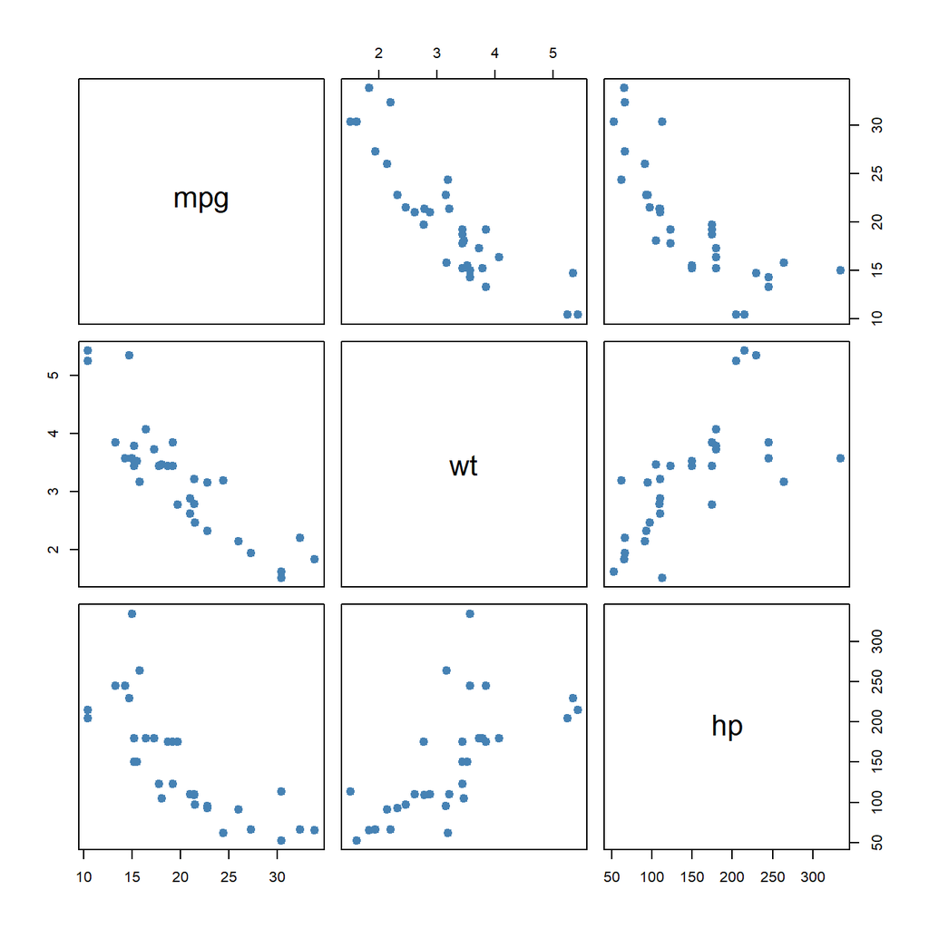

```r
pairs(mtcars_df[, c("mpg", "wt", "hp")],
      pch = 19, col = "steelblue", cex = 1.3, cex.labels = 2)
```

# 3. Fit the multiple linear regression

```r
model <- fit_model(mtcars_df)
summary(model)
```

```
##
## Call:
## lm(formula = f, data = data)
##
## Residuals:
##    Min     1Q Median     3Q    Max
## -3.941 -1.600 -0.182  1.050  5.854
##
## Coefficients:
##             Estimate Std. Error t value Pr(>|t|)
## (Intercept) 37.22727    1.59879  23.285  < 2e-16 ***
## wt          -3.87783    0.63273  -6.129 1.12e-06 ***
## hp          -0.03177    0.00903  -3.519  0.00145 **
## ---
## Signif. codes:  0 '***' 0.001 '**' 0.01 '*' 0.05 '.' 0.1 ' ' 1
##
## Residual standard error: 2.593 on 29 degrees of freedom
## Multiple R-squared:  0.8268, Adjusted R-squared:  0.8148
## F-statistic: 69.21 on 2 and 29 DF,  p-value: 9.109e-12
```

```r
confint(model)
```

```
##                   2.5 %      97.5 %
## (Intercept) 33.95738245 40.49715778
## wt          -5.17191604 -2.58374544
## hp          -0.05024078 -0.01330512
```

# 4. Check the assumptions

## 4.1 Diagnostic plots

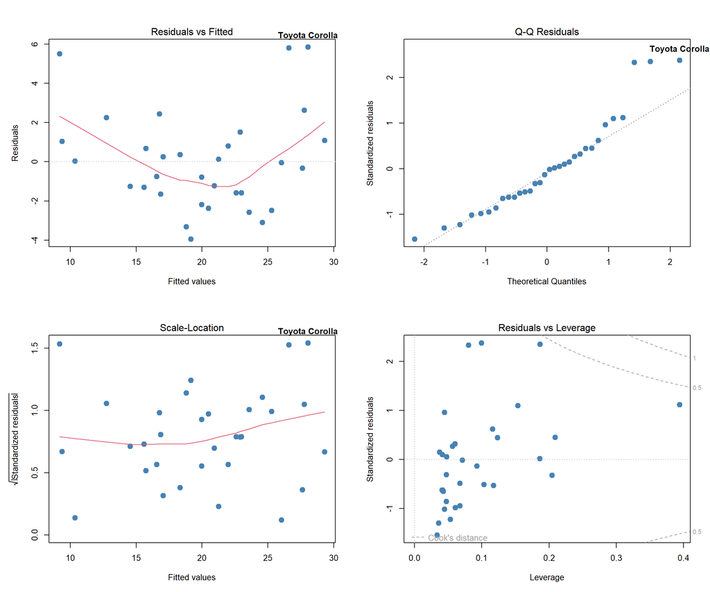

```r
plot_diagnostics(model)
```

To also save a high-resolution copy as an image file, run:

```r
plot_diagnostics(model, file = "diagnostics.png")
```

## 4.2 Multicollinearity and normality

```r
tests <- run_tests(model)
tests
```

```
## $vif
##       wt       hp
## 1.766625 1.766625
##
## $shapiro
##
##  Shapiro-Wilk normality test
##
## data:  residuals(model)
## W = 0.92792, p-value = 0.03427
```

# 5. Interpretation

- **Intercept:** predicted mpg when weight and horsepower are both 0 (not meaningful in practice).
- **wt:** holding horsepower constant, each additional 1,000 lbs is associated with a drop in mpg of about the estimated coefficient.
- **hp:** holding weight constant, each additional horsepower is associated with a small drop in mpg.
- **R² / adjusted R²:** the share of variation in mpg explained by the model.
- **F-test:** whether the model as a whole predicts mpg better than no predictors.
- **Assumptions:** discuss any curvature in Residuals vs Fitted, the Q-Q plot, the VIF values, the Shapiro-Wilk p-value, and influential cars.
- **Caveats:** only 32 cars from 1974, and the results show association, not causation.

# 6. Debugging the functions

## 6.1 Automated test of all functions

Runs each function with good and bad inputs and reports PASS, FAIL, or WARN. The bad-input rows **should** say FAIL with a clear message, which shows the validation works.

```r
test_all <- function() {
  results <- list()

  check <- function(label, expr) {
    out <- tryCatch({ force(expr); "PASS" },
                    error   = function(e) paste("FAIL:", conditionMessage(e)),
                    warning = function(w) paste("WARN:", conditionMessage(w)))
    results[[label]] <<- out
  }

  d <- load_data()
  m <- fit_model(d)

  # Normal use
  check("load_data()",                 load_data())
  check("fit_model() good input",      fit_model(d))
  check("plot_diagnostics() good",     plot_diagnostics(m, tempfile(fileext = ".png")))
  check("run_tests() good",            run_tests(m))

  # Deliberately bad input
  check("fit_model() bad column",      fit_model(d, predictors = c("weight", "hp")))
  check("fit_model() one predictor",   fit_model(d, predictors = "wt"))
  check("fit_model() not a data.frame", fit_model(as.matrix(d)))
  check("plot_diagnostics() not lm",   plot_diagnostics("not a model"))
  check("run_tests() not lm",          run_tests(42))

  data.frame(test = names(results), result = unlist(results), row.names = NULL)
}

test_all()
```

| test | result |
| --- | --- |
| load_data() | PASS |
| fit_model() good input | PASS |
| plot_diagnostics() good | PASS |
| run_tests() good | PASS |
| fit_model() bad column | FAIL: Column(s) not found in data: weight |
| fit_model() one predictor | FAIL: length(predictors) >= 2 is not TRUE |
| fit_model() not a data.frame | FAIL: is.data.frame(data) is not TRUE |
| plot_diagnostics() not lm | FAIL: inherits(model, "lm") is not TRUE |
| run_tests() not lm | FAIL: inherits(model, "lm") is not TRUE |

## 6.2 Catch an error and see where it came from

`traceback()` only works interactively, so inside a knitted document we catch the error and print the call that caused it.

```r
tryCatch(
  fit_model(mtcars_df, predictors = c("weight", "hp")),
  error = function(e) {
    cat("Error message:", conditionMessage(e), "\n")
    cat("Raised in call:", deparse(conditionCall(e)), "\n")
  }
)
```

```
## Error message: Column(s) not found in data: weight
## Raised in call: fit_model(mtcars_df, predictors = c("weight", "hp"))
```

## 6.3 Switch debugging on and off for every function

```r
fns <- c("load_data", "fit_model", "plot_diagnostics", "run_tests")

invisible(lapply(fns, debug))            # turn debugging ON
sapply(fns, isdebugged)                  # confirm
```

```
##        load_data        fit_model plot_diagnostics        run_tests
##             TRUE             TRUE             TRUE             TRUE
```

```r
invisible(lapply(fns, undebug))          # turn debugging OFF
sapply(fns, isdebugged)                  # confirm it is off
```

```
##        load_data        fit_model plot_diagnostics        run_tests
##            FALSE            FALSE            FALSE            FALSE
```

## 6.4 Watch a function without editing it

```r
trace("fit_model",
      quote(cat("Fitting with predictors:", predictors, "\n")),
      print = FALSE)
```

```
## [1] "fit_model"
```

```r
invisible(fit_model(mtcars_df))
```

```
## Fitting with predictors: wt hp
```

```r
untrace("fit_model")
```

## 6.5 Interactive debugging (run these in the R console, not when knitting)

These open the `Browse[2]>` prompt, which needs a live R session, so the chunks are set to `eval=FALSE`.

```r
debugonce(load_data);        load_data()
debugonce(fit_model);        m <- fit_model(mtcars)
debugonce(plot_diagnostics); plot_diagnostics(m)
debugonce(run_tests);        run_tests(m)
```

| Command | Action |
| --- | --- |
| `n` or Enter | run the next line |
| `s` | step into a function call |
| `c` | continue to the end of the function |
| `Q` | quit the debugger |
| `ls()` | list local variables |
| `print(x)` | inspect a variable |

Pause at an exact line by adding `browser()` inside a function, for example just before `lm()` in `fit_model()`. A conditional version, `if (anyNA(data)) browser()`, only stops when something is wrong.

To enter the debugger automatically on any error, and to turn it off afterwards:

```r
options(error = recover)
options(error = NULL)
```